# Predicting Flight Delays (*a Proof-of-Concept*)

Author: Solomon Heng

# Regression Modeling (single route, LGA)

```python
import pandas as pd
import numpy as np
import matplotlib.pyplot as plt
import seaborn as sns

from sklearn.preprocessing import StandardScaler
from sklearn.linear_model import LinearRegression
from sklearn.model_selection import train_test_split, cross_val_score, RandomizedSearchCV
from sklearn.feature_selection import RFE
from sklearn.metrics import mean_squared_error
from sklearn.ensemble import RandomForestRegressor
from sklearn.preprocessing import PowerTransformer

from keras.models import Sequential
from keras.layers import Dense, Dropout
from keras.callbacks import EarlyStopping
from keras import backend as K

import xgboost as xgb

import scipy.stats as stats

import pickle

from yellowbrick.regressor import ResidualsPlot

sns.set()
```

```python
df = pd.read_csv('../datasets/combined_featureselect_data_regression_lga.csv')
df_test = pd.read_csv('../datasets/combined_featureselect_data_regression_test_lga.csv')
```

```python
pd.set_option('display.max_columns', 100)
df.head()
```

|  | DEPARTURE_DELAY | LATE_AIRCRAFT_DELAY | squall | SCHEDULED_ARRIVAL_MONTH_sin | SCHEDULED_ARRIVAL_MONTH_cos | SCHEDULED_ARRIVAL_HOUR_sin | SCHEDULED_ARRIVAL_HOUR_cos | DEPARTURE_DELAY^2 | DEPARTURE_DELAY SCHEDULED_TIME | DEPARTURE_DELAY DISTANCE | DEPARTURE_DELAY QNH | DEPARTURE_DELAY dew_point | DEPARTURE_DELAY visibility | DEPARTURE_DELAY temp | DEPARTURE_DELAY winddir | DEPARTURE_DELAY windspd | DEPARTURE_DELAY NUM_ARR_AVG_3HOUR | DEPARTURE_DELAY crosswind_comp | SCHEDULED_TIME LATE_AIRCRAFT_DELAY | DISTANCE LATE_AIRCRAFT_DELAY | LATE_AIRCRAFT_DELAY QNH | LATE_AIRCRAFT_DELAY visibility | LATE_AIRCRAFT_DELAY NUM_ARR_AVG_3HOUR | ARRIVAL_DELAY |
| --- | --- | --- | --- | --- | --- | --- | --- | --- | --- | --- | --- | --- | --- | --- | --- | --- | --- | --- | --- | --- | --- | --- | --- | --- |
| 0 | 0.398518 | -0.247673 | -0.745356 | 0.642772 | 1.360073 | -0.330134 | 1.417370 | -0.063348 | 0.443981 | 0.398518 | 0.408443 | -0.900765 | 0.480920 | -0.388845 | -0.029999 | 0.247510 | 0.157069 | -0.094748 | -0.246675 | -0.247673 | -0.247664 | -0.230578 | -0.231999 | 8.0 |
| 1 | -0.347958 | -0.247673 | -0.745356 | -0.812155 | -1.059130 | -0.528123 | -0.806295 | -0.115914 | -0.345408 | -0.347958 | -0.347614 | -0.260882 | -0.335578 | -0.306167 | -0.297726 | -0.280182 | -0.336695 | -0.256548 | -0.246675 | -0.247673 | -0.247664 | -0.230578 | -0.231999 | -29.0 |
| 2 | -0.327223 | -0.247673 | -0.745356 | 1.175313 | -0.547893 | -0.705239 | 1.182927 | -0.116051 | -0.326763 | -0.327223 | -0.327190 | -0.226868 | -0.312898 | -0.277042 | -0.299624 | -0.270318 | -0.315068 | -0.243296 | -0.246675 | -0.247673 | -0.247664 | -0.230578 | -0.231999 | 8.0 |
| 3 | 1.124259 | 1.092610 | -0.745356 | 0.642772 | 1.360073 | -0.858181 | -0.534796 | 0.101151 | 1.033062 | 1.124259 | 1.129515 | -0.580823 | 1.274737 | -0.196243 | 1.742503 | 1.786200 | 1.447968 | 1.825888 | 1.012208 | 1.092610 | 1.098355 | 1.221338 | 1.402382 | 68.0 |
| 4 | -0.057662 | -0.247673 | -0.745356 | -0.084692 | -1.246256 | -0.330134 | 1.417370 | -0.109526 | -0.074300 | -0.057662 | -0.057948 | -0.010030 | -0.018051 | 0.054611 | 0.019369 | -0.107572 | -0.036513 | -0.231698 | -0.246675 | -0.247673 | -0.247664 | -0.230578 | -0.231999 | -14.0 |

```python
df.shape
```

```
(6342, 24)
```

## Only looking at delays (<420 mins)

*Rationale: Customers would have to be compensated after delays exceed 3 hours (for EU). Since we are looking at US and they DO NOT have any form of obligated compensation for flight delays, we shall use 420mins(7hours) as a benchmark. Also, if delays are long, airlines would likely reschedule the departure to a later timing.*

```python
df = df[(df['ARRIVAL_DELAY']<420)]
df_test = df_test[(df_test['ARRIVAL_DELAY']<420)]
```

```python
df.ARRIVAL_DELAY.mean()
```

```
1.9568856601389766
```

```python
df_test.ARRIVAL_DELAY.mean()
```

```
2.9747634069400632
```

## Setting X_train, X_test, y_train & y_test

```python
X_train = df.drop('ARRIVAL_DELAY', axis=1)
y_train = df['ARRIVAL_DELAY']
X_test = df_test.drop('ARRIVAL_DELAY', axis=1)
y_test = df_test['ARRIVAL_DELAY']
```

```python
X_train.shape
```

```
(6332, 23)
```

```python
X_test.shape
```

```
(1585, 23)
```

## Attempting Box Cox transformation

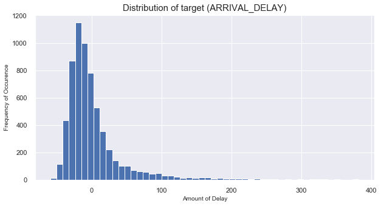

```python
plt.figure(figsize=(10,5))
plt.hist(y_train, bins=50)
plt.title("Distribution of target (ARRIVAL_DELAY)", fontsize=15)
plt.xlabel("Amount of Delay", fontsize=10)
plt.ylabel("Frequency of Occurence", fontsize=10);

# Not normally distributed
```

```python
pt = PowerTransformer()
```

```python
y = np.asarray(y_train).reshape(-1,1)
yt = np.asarray(y_test).reshape(-1,1)
```

```python
y_train = pt.fit_transform(y)
y_test = pt.transform(yt)
```

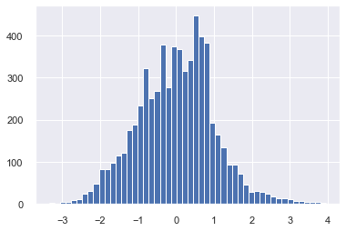

```python
plt.hist(y_train, bins=50);
```

## Model (1): Linear Regression

```python
lr = LinearRegression()
lr.fit(X_train, y_train)
```

```
LinearRegression(copy_X=True, fit_intercept=True, n_jobs=None, normalize=False)
```

```python
np.sqrt(-cross_val_score(lr, X_train, y_train, scoring='neg_mean_squared_error').mean())
```

```
0.7020636269488388
```

```python
# R^2 Score
lr.score(X_test, y_test)
```

```
0.5143006430972409
```

```python
# RMSE Score
np.sqrt(mean_squared_error(y_test, lr.predict(X_test)))
```

```
0.6901117621902141
```

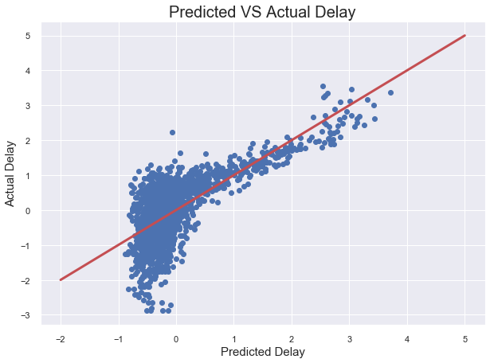

```python
# Visualizing our Predictions vs Actual
pred = lr.predict(X_test)

plt.figure(figsize=(10,7))

plt.scatter(pred,y_test)
plt.plot((-2,5), (-2, 5), c='r', linewidth=3)
plt.xlabel('Predicted Delay', fontsize=15)
plt.ylabel('Actual Delay', fontsize=15)
plt.title('Predicted VS Actual Delay', fontsize=20);
```

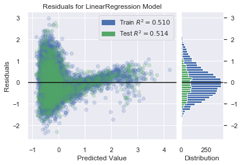

```python
# Visualizing distribution of errors

visualizer = ResidualsPlot(lr, train_alpha=0.2, test_alpha=0.2)

visualizer.fit(X_train, y_train)  # Fit the training data to the visualizer
visualizer.score(X_test, y_test)  # Evaluate the model on the test data
visualizer.show();
```

**Seemingly a very badly model for our problem at hand**

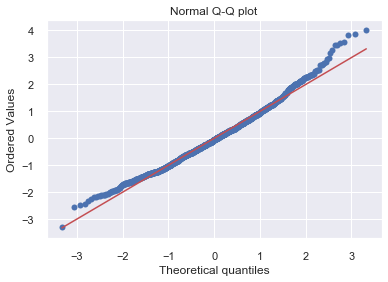

```python
resid = pred.reshape(1585,)-y_test.reshape(1585,)

z = (resid-np.mean(resid))/np.std(resid)

stats.probplot(z, dist="norm", plot=plt)
plt.title("Normal Q-Q plot")
plt.show()
```

## Model (2): RandomForest Regression

```python
rf = RandomForestRegressor()
```

```python
rf_params = {
  "n_estimators":[50,100],
  "min_samples_split":[10,20],
  "max_depth":[5,10]
}

rf_cv = RandomizedSearchCV(rf, param_distributions=rf_params, n_iter=2, n_jobs=4, verbose=2)
```

```python
rf_cv.fit(X_train, y_train)
```

```
Fitting 5 folds for each of 2 candidates, totalling 10 fits
```

```
[Parallel(n_jobs=4)]: Using backend LokyBackend with 4 concurrent workers.
[Parallel(n_jobs=4)]: Done  10 out of  10 | elapsed:    9.6s finished
```

```
RandomizedSearchCV(cv=None, error_score=nan,
                   estimator=RandomForestRegressor(bootstrap=True,
                                                   ccp_alpha=0.0,
                                                   criterion='mse',
                                                   max_depth=None,
                                                   max_features='auto',
                                                   max_leaf_nodes=None,
                                                   max_samples=None,
                                                   min_impurity_decrease=0.0,
                                                   min_impurity_split=None,
                                                   min_samples_leaf=1,
                                                   min_samples_split=2,
                                                   min_weight_fraction_leaf=0.0,
                                                   n_estimators=100,
                                                   n_jobs=None, oob_score=False,
                                                   random_state=None, verbose=0,
                                                   warm_start=False),
                   iid='deprecated', n_iter=2, n_jobs=4,
                   param_distributions={'max_depth': [5, 10],
                                        'min_samples_split': [10, 20],
                                        'n_estimators': [50, 100]},
                   pre_dispatch='2*n_jobs', random_state=None, refit=True,
                   return_train_score=False, scoring=None, verbose=2)
```

```python
rf_cv.best_params_
```

```
{'n_estimators': 100, 'min_samples_split': 20, 'max_depth': 10}
```

```python
opt_rf = RandomForestRegressor(n_estimators=100, min_samples_split=20, max_depth=10) # CHANGE TO 100, 20, 10 PLS -SOLO
```

```python
opt_rf.fit(X_train, y_train)
```

```
RandomForestRegressor(bootstrap=True, ccp_alpha=0.0, criterion='mse',
                      max_depth=10, max_features='auto', max_leaf_nodes=None,
                      max_samples=None, min_impurity_decrease=0.0,
                      min_impurity_split=None, min_samples_leaf=1,
                      min_samples_split=20, min_weight_fraction_leaf=0.0,
                      n_estimators=100, n_jobs=None, oob_score=False,
                      random_state=None, verbose=0, warm_start=False)
```

```python
np.sqrt(-cross_val_score(opt_rf, X_train, y_train, scoring='neg_mean_squared_error').mean())
```

```
0.6506408629686042
```

```python
# R^2 Score
opt_rf.score(X_test, y_test)
```

```
0.5848945989339214
```

```python
# RMSE Score
np.sqrt(mean_squared_error(y_test, opt_rf.predict(X_test)))
```

```
0.6379914482433052
```

```python
# RMSE in minutes
pt.inverse_transform([[0.6385938157578391]])
```

```
array([[7.62434506]])
```

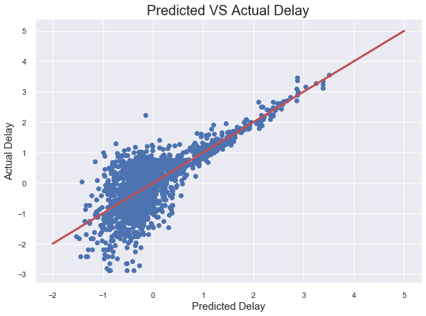

```python
# Visualizing our Predictions vs Actual
pred = opt_rf.predict(X_test)

plt.figure(figsize=(10,7))

plt.scatter(pred,y_test)
plt.plot((-2,5), (-2, 5), c='r', linewidth=3)
plt.xlabel('Predicted Delay', fontsize=15)
plt.ylabel('Actual Delay', fontsize=15)
plt.title('Predicted VS Actual Delay', fontsize=20);
```

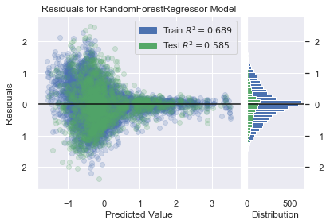

```python
# Visualizing distribution of errors

visualizer = ResidualsPlot(opt_rf, train_alpha=0.2, test_alpha=0.2)

visualizer.fit(X_train, y_train.reshape(6332,))  # Fit the training data to the visualizer
visualizer.score(X_test, y_test.reshape(1585,))  # Evaluate the model on the test data
visualizer.show();
```

```python
# Predicted value at 1SD
pt.inverse_transform([[1]])
```

```
array([[32.83919607]])
```

**When the delays are low, there are too many possible factors affecting the amount of delays *(e.g pilot mistakes, ATC mistakes, another aircraft on the taxiway causing delays)*. As the delays increase, the possibilities/noise are "even-ed" out by more stable concrete factors. Hence the decrease of variance in prediction as time proceeds on. I believe this heteroscadastic nature is nearly impossible to handle without decreasing the RMSE of the model (which would likely render the model useless practically).**

**Hence to work-around this issue, We can perhaps follow a guideline of only trusting the model**

**1. when the predictions are above the 1 SD mark (or when predicted delays are >33mins).**

**2. OR we can build a multiclass classification model to help bin the delays into 1 hour periods _(which we will do in another model)_.**

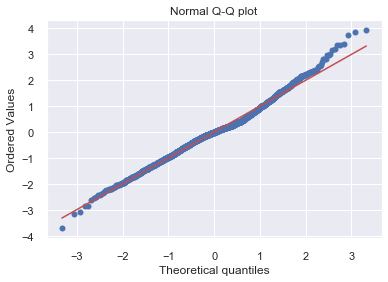

```python
resid = pred.reshape(1585,)-y_test.reshape(1585,)

z = (resid-np.mean(resid))/np.std(resid)

stats.probplot(z, dist="norm", plot=plt)
plt.title("Normal Q-Q plot")
plt.show()
```

```python
# Exporting model

# rf_filename = '../models/regression_lga_rf_model.sav'
# pickle.dump(opt_rf, open(rf_filename, 'wb'))
```

## Model (3): XGB Regression

```python
xgbr = xgb.XGBRegressor()
```

```python
xgbr_params = {
  "learning_rate":[0.01, 0.1, 0.2, 0.3],
  "max_depth":[3, 5, 10]
}

xgbr_cv = RandomizedSearchCV(xgbr, param_distributions=xgbr_params, n_iter=2, n_jobs=4, verbose=2)
```

```python
xgbr_cv.fit(X_train, y_train)
```

```
Fitting 5 folds for each of 2 candidates, totalling 10 fits
```

```
[Parallel(n_jobs=4)]: Using backend LokyBackend with 4 concurrent workers.
[Parallel(n_jobs=4)]: Done  10 out of  10 | elapsed:    2.9s finished
```

```
[14:19:46] WARNING: C:/Jenkins/workspace/xgboost-win64_release_0.90/src/objective/regression_obj.cu:152: reg:linear is now deprecated in favor of reg:squarederror.
```

```
RandomizedSearchCV(cv=None, error_score=nan,
                   estimator=XGBRegressor(base_score=0.5, booster='gbtree',
                                          colsample_bylevel=1,
                                          colsample_bynode=1,
                                          colsample_bytree=1, gamma=0,
                                          importance_type='gain',
                                          learning_rate=0.1, max_delta_step=0,
                                          max_depth=3, min_child_weight=1,
                                          missing=None, n_estimators=100,
                                          n_jobs=1, nthread=None,
                                          objective='reg:linear',
                                          random_state=0, reg_alpha=0,
                                          reg_lambda=1, scale_pos_weight=1,
                                          seed=None, silent=None, subsample=1,
                                          verbosity=1),
                   iid='deprecated', n_iter=2, n_jobs=4,
                   param_distributions={'learning_rate': [0.01, 0.1, 0.2, 0.3],
                                        'max_depth': [3, 5, 10]},
                   pre_dispatch='2*n_jobs', random_state=None, refit=True,
                   return_train_score=False, scoring=None, verbose=2)
```

```python
xgbr_cv.best_params_
```

```
{'max_depth': 3, 'learning_rate': 0.2}
```

```python
opt_xgb = xgb.XGBRegressor(max_depth=5, learning_rate=0.1)
```

```python
opt_xgb.fit(X_train, y_train)
```

```
[14:19:46] WARNING: C:/Jenkins/workspace/xgboost-win64_release_0.90/src/objective/regression_obj.cu:152: reg:linear is now deprecated in favor of reg:squarederror.
```

```
XGBRegressor(base_score=0.5, booster='gbtree', colsample_bylevel=1,
             colsample_bynode=1, colsample_bytree=1, gamma=0,
             importance_type='gain', learning_rate=0.1, max_delta_step=0,
             max_depth=5, min_child_weight=1, missing=None, n_estimators=100,
             n_jobs=1, nthread=None, objective='reg:linear', random_state=0,
             reg_alpha=0, reg_lambda=1, scale_pos_weight=1, seed=None,
             silent=None, subsample=1, verbosity=1)
```

```python
np.sqrt(-cross_val_score(opt_xgb, X_train, y_train, scoring='neg_mean_squared_error').mean())
```

[output not shown]

```
0.6516561476837415
```

```python
# R^2 Score
opt_xgb.score(X_test, y_test)
```

```
0.5877682505288369
```

```python
# RMSE Score
np.sqrt(mean_squared_error(y_test, opt_xgb.predict(X_test)))
```

```
0.635779300281177
```

```python
# RMSE in minutes
pt.inverse_transform([[0.635779300281177]])
```

```
array([[7.46372165]])
```

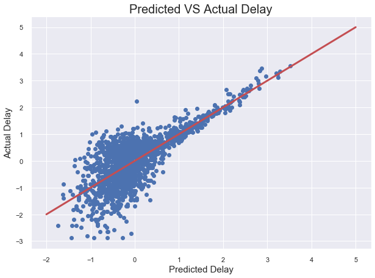

```python
# Visualizing our Predictions vs Actual
pred = opt_xgb.predict(X_test)

plt.figure(figsize=(10,7))

plt.scatter(pred,y_test)
plt.plot((-2,5), (-2, 5), c='r', linewidth=3)
plt.xlabel('Predicted Delay', fontsize=15)
plt.ylabel('Actual Delay', fontsize=15)
plt.title('Predicted VS Actual Delay', fontsize=20);
```

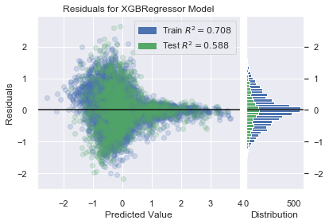

```python
# Visualizing distribution of errors

visualizer = ResidualsPlot(opt_xgb, train_alpha=0.2, test_alpha=0.2)

visualizer.fit(X_train, y_train.reshape(6332,))  # Fit the training data to the visualizer
visualizer.score(X_test, y_test.reshape(1585,))  # Evaluate the model on the test data
visualizer.show();
```

```python
# Predicted value at 1SD
pt.inverse_transform([[1]])
```

```
array([[32.83919607]])
```

**When the delays are low, there are too many possible factors affecting the amount of delays *(e.g pilot mistakes, ATC mistakes, another aircraft on the taxiway causing delays)*. As the delays increase, the possibilities/noise are "even-ed" out by more stable concrete factors. Hence the decrease of variance in prediction as time proceeds on. I believe this heteroscadastic nature is nearly impossible to handle without decreasing the RMSE of the model (which would likely render the model useless practically).**

**Hence to work-around this issue, We can perhaps follow a guideline of only trusting the model**

**1. when the predictions are above the 1 SD mark (or when predicted delays are >33mins).**

**2. OR we can build a multiclass classification model to help bin the delays into 1 hour periods _(which we will do in another model)_.**

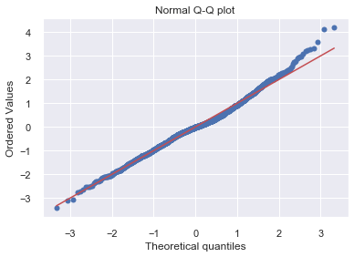

```python
resid = pred.reshape(1585,)-y_test.reshape(1585,)

z = (resid-np.mean(resid))/np.std(resid)

stats.probplot(z, dist="norm", plot=plt)
plt.title("Normal Q-Q plot")
plt.show()
```

```python
# Exporting model

# xgb_filename = '../models/regression_lga_xgb_model.sav'
# pickle.dump(opt_xgb, open(xgb_filename, 'wb'))
```

## Model (4): Neural Network

```python
model = Sequential()
```

```python
model.add(Dense(20,
                input_dim=23,
                activation='relu'))

# model.add(Dropout(0.5))

model.add(Dense(20,
                activation='relu'))

#model.add(Dropout(0.5))

#model.add(Dense(150,
                #activation='relu'))

# Can include dropout (Nope, performed poorer)

model.add(Dense(1))
```

```python
def root_mean_squared_error(y_true, y_pred):
        return K.sqrt(K.mean(K.square(y_pred - y_true)))
```

```python
es = EarlyStopping(monitor='val_loss', patience=3)

model.compile(optimizer='adam', loss=root_mean_squared_error, metrics=['mse', 'mae'])
```

```python
model.fit(X_train, y_train, batch_size=32, epochs=1000, validation_split=0.2, callbacks=[es])
```

```
Train on 5065 samples, validate on 1267 samples
```

```
<keras.callbacks.callbacks.History at 0x1d13b9b8b08>
```

```python
model.evaluate(X_test, y_test)
```

```
[0.6586954224372887, 0.4461747705936432, 0.5112867951393127]
```

```python
# RMSE in minutes
pt.inverse_transform([[0.6629781692750071]])
```

```
array([[9.04582232]])
```

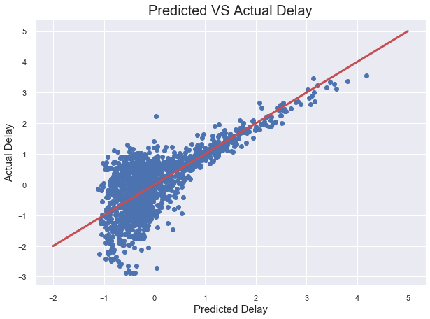

```python
# Visualizing our Predictions vs Actual
pred = model.predict(X_test)

plt.figure(figsize=(10,7))

plt.scatter(pred,y_test)
plt.plot((-2,5), (-2, 5), c='r', linewidth=3)
plt.xlabel('Predicted Delay', fontsize=15)
plt.ylabel('Actual Delay', fontsize=15)
plt.title('Predicted VS Actual Delay', fontsize=20);
```

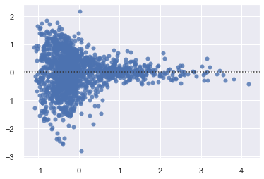

```python
sns.residplot(pred, y_test)
```

```python
# Predicted value at 1SD
pt.inverse_transform([[1]])
```

```
array([[32.83919607]])
```

**When the delays are low, there are too many possible factors affecting the amount of delays *(e.g pilot mistakes, ATC mistakes, another aircraft on the taxiway causing delays)*. As the delays increase, the possibilities/noise are "even-ed" out by more stable concrete factors. Hence the decrease of variance in prediction as time proceeds on. I believe this heteroscadastic nature is nearly impossible to handle without decreasing the RMSE of the model (which would likely render the model useless practically).**

**Hence to work-around this issue, We can perhaps follow a guideline of only trusting the model**

**1. when the predictions are above the 1 SD mark (or when predicted delays are >33mins).**

**2. OR we can build a multiclass classification model to help bin the delays into 1 hour periods _(which we will do in another model)_.**

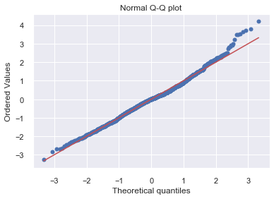

```python
resid = pred.reshape(1585,)-y_test.reshape(1585,)

z = (resid-np.mean(resid))/np.std(resid)

stats.probplot(z, dist="norm", plot=plt)
plt.title("Normal Q-Q plot")
plt.show()
```

```python
# Exporting model

#nn_filename = '../models/regression_nn_model.sav'
#pickle.dump(model, open(nn_filename, 'wb'))
```